# stats-privacy

Zhiyuan Zhou

# 1. Basic Ideas of Statistical Privacy

## k-Anonymity

### Intuitive Explanation

- A dataset has **k-anonymity** if every individual’s record is indistinguishable from at least **k−1 other records** based on certain identifying attributes (like age, ZIP code, gender).
- Example: If `k=5`, then any given row looks identical to at least 4 other rows when considering quasi-identifiers.

### Technical Notes

- Achieved by **generalization** (e.g., grouping ages into ranges) and **suppression** (removing some details).
- Formally: For any combination of quasi-identifiers, the frequency count ≥ k.
- Limitation: Vulnerable to **homogeneity attacks** (when all records in a group have the same sensitive attribute).

```r
# Example: grouping ages for k-anonymity
ages <- c(22, 23, 24, 25, 48, 49, 50, 51)
age_group <- cut(ages, breaks = c(20,30,40,60), labels = c("20-30","30-40","40-60"))
data.frame(ages, age_group)
```

```
##   ages age_group
## 1   22     20-30
## 2   23     20-30
## 3   24     20-30
## 4   25     20-30
## 5   48     40-60
## 6   49     40-60
## 7   50     40-60
## 8   51     40-60
```

## l-Diversity

### Intuitive Explanation

- Builds on k-anonymity. Even if a group has ≥ k people, privacy is weak if all have the same sensitive value.
- **l-diversity** ensures that sensitive attributes within each group are sufficiently varied.

### Technical Notes

- A dataset is l-diverse if every equivalence class contains at least **l “well-represented” sensitive values**.
- Models:
  - **Distinct l-diversity**: at least l distinct sensitive values.
  - **Entropy l-diversity**: ensures distribution of sensitive values is not skewed.

## SUDA

### Intuitive Explanation

- Detects records that are **“special uniques”**—unusual combinations of attributes that may make someone re-identifiable.
- Example: Being the *only* 42-year-old neurosurgeon in a ZIP code.

### Technical Notes

- SUDA (Special Uniques Detection Algorithm) looks for **minimal unique combinations** of attributes.
- Assigns **risk scores** to records depending on how often they appear across different subsets of variables.
- Often used in **statistical disclosure control** for government/microdata releases.

## Differential Privacy

### Intuitive Explanation

- A strong, mathematically rigorous notion of privacy.
- A mechanism is **differentially private** if the inclusion or exclusion of a single individual **barely changes** the output.
- Think of it as adding “just enough noise” to mask individuals but still reveal population trends.

### Technical Notes

- Definition: A randomized mechanism **M** is (ε, δ)-differentially private if:

$$P[M(D) ∈ S] ≤ e^ε * P[M(D′) ∈ S] +
δ$$

- Common techniques:
  - **Laplace mechanism**
  - **Gaussian mechanism**
  - **Privacy budgets (ε)**

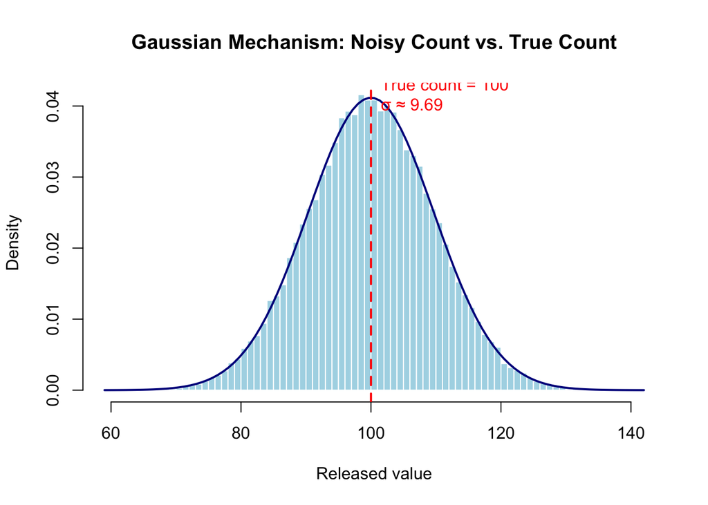

```r
# Example: Gaussian mechanism for noisy counts
# We add N(0, σ^2) noise where σ = sqrt(2*log(1.25/δ)) * (Δ2f / ε)
# Here, Δ2f (L2-sensitivity) = 1 for a count query.
count <- 100
l2_sensitivity <- 1
epsilon <- 0.5
delta <- 1e-5
sigma <- sqrt(2*log(1.25/delta)) * l2_sensitivity / epsilon

set.seed(123)
n <- 50000
noisy <- count + rnorm(n, mean = 0, sd = sigma)

# Plot
hist(noisy, breaks = 100, freq = FALSE,
     main = "Gaussian Mechanism: Noisy Count vs. True Count",
     xlab = "Released value", col = "lightblue", border = "white")

curve(dnorm(x, mean = count, sd = sigma),
      add = TRUE, lwd = 2, col = "darkblue")

abline(v = count, lty = 2, lwd = 2, col = "red")

text(count, max(density(noisy)$y),
     labels = paste0("True count = ", count, "\nσ ≈ ", round(sigma, 2)),
     pos = 4, col = "red")
```

## Synthetic Data

### Intuitive Explanation

- Instead of sharing real data, create **artificial datasets** that mimic the statistical properties of the original.
- Example: Instead of releasing actual patient records, generate synthetic patients whose values preserve correlations.

### Technical Notes

- Methods:
  - **Parametric models** (e.g., regression-based synthesis)
  - **Non-parametric methods** (e.g., resampling, decision trees)
  - **Generative models** (GANs, variational autoencoders)
- Tradeoff: Utility vs. disclosure risk—synthetic data must be tested to ensure it doesn’t “leak” real individuals.

```r
# Example: simple synthetic dataset
data <- data.frame(age = rnorm(100, mean = 50, sd = 10),
                   income = rnorm(100, mean = 60000, sd = 15000))
head(data)
```

```
##        age   income
## 1 52.59590 37499.11
## 2 59.17511 67436.81
## 3 42.77682 60192.21
## 4 41.91716 62246.94
## 5 48.58648 66672.59
## 6 72.57013 68890.74
```

# 2. Walk-through Example